# Projekt zaliczeniowy

Wybrane pakiety do analizy danych 2024

Alicja Czuż 417140

31 marzec, 2026

# Wybór i opis zbioru danych

Dostępnych jest 10 zbiorów danych. Do opracowania należy wybrać ten, którego numer jest równy **ostatniej cyfrze numeru indeksu**

Zbiór danych zawiera następujące informacje o studentach:

1. Numer_indeksu: unikalny numer indeksu studenta (liczba sześciocyfrowa).
2. Płeć: Płeć studenta, tj. “Kobieta” lub “Mężczyzna”.
3. Kierunek_studiów: kierunek, na którym studiuje student. Możliwe kierunki to: “Informatyka”, “Ekonomia”, “Psychologia”, “Biologia”.
4. Wiek: wiek studenta.
5. Czas_nauki: ilość godzin nauki tygodniowo.
6. Średnia_ocen: średnia ocen studenta.

# Przygotowanie danych

## Zadania

- Załaduj dane (kod, bez kreatora) i przekształć zmienne jakościowe na typ `factor`.
- Wyświetl podsumowanie danych. Na podstawie tego określ, które zmienne są jakościowe, a które ilościowe.

## Rozwiązania

```r
library("openxlsx")



dane <- read.xlsx("preferencje_studentow_z_srednia_ocen0.xlsx")

dane$Płeć <- factor(dane$Płeć)
dane$Kierunek_studiów <- factor(dane$Kierunek_studiów)

str(dane)
```

```
## 'data.frame':    500 obs. of  6 variables:
##  $ Numer_indeksu   : num  110001 110002 110003 110004 110005 ...
##  $ Płeć            : Factor w/ 2 levels "Kobieta","Mężczyzna": 1 2 1 1 1 1 1 1 1 2 ...
##  $ Kierunek_studiów: Factor w/ 4 levels "Biologia","Ekonomia",..: 2 2 2 2 3 NA 2 2 4 3 ...
##  $ Wiek            : num  23 20 21 22 20 21 24 20 22 21 ...
##  $ Czas_nauki      : num  3.83 4.7 3.14 5.35 22.65 ...
##  $ Średnia_ocen    : num  3.48 3.01 4.17 4.39 5 4.79 4.34 3.67 3.54 2.83 ...
```

```r
summary(dane)
```

```
##  Numer_indeksu           Płeć        Kierunek_studiów      Wiek
##  Min.   :110001   Kobieta  :402   Biologia   :116     Min.   :15.00
##  1st Qu.:110126   Mężczyzna: 94   Ekonomia   :122     1st Qu.:20.00
##  Median :110251   NA's     :  4   Informatyka:131     Median :21.00
##  Mean   :110251                   Psychologia:119     Mean   :20.94
##  3rd Qu.:110375                   NA's       : 12     3rd Qu.:22.00
##  Max.   :110500                                       Max.   :27.00
##                                                       NA's   :13
##    Czas_nauki     Średnia_ocen
##  Min.   : 0.05   Min.   :2.000
##  1st Qu.: 2.56   1st Qu.:3.290
##  Median : 4.35   Median :3.855
##  Mean   : 4.82   Mean   :3.836
##  3rd Qu.: 6.15   3rd Qu.:4.420
##  Max.   :27.99   Max.   :5.000
##  NA's   :11      NA's   :10
```

Dane ilościowe to : Numer_indeksu, Wiek, Czas_nauki, Średnia-ocen

Dane jakościowe to: Płeć i kierunek.

# Obsługa brakujących danych

## Zadania

Sprawdź, czy w zestawie danych występują wartości `NA`. Jeśli tak:

- Dla zmiennych jakościowych zastąp brakujące wartości najczęściej występującą kategorią.
- Dla zmiennych ilościowych zastąp brakujące wartości średnią. Pamiętaj, aby dla zmiennej “wiek” średnia była zaokrąglona do pełnych wartości.

## Rozwiązania

```r
library(Hmisc)
sum(is.na(dane))
```

```
## [1] 50
```

```r
#Występuje 50 braków

#DLa zmiennych ilościowych
dane$Wiek=impute(dane$Wiek, mean)
dane$Wiek=as.numeric(round(dane$Wiek))
dane$Czas_nauki=impute(dane$Czas_nauki, mean)
dane$Czas_nauki=as.numeric(dane$Czas_nauki)
dane$Średnia_ocen=impute(dane$Średnia_ocen, mean)
dane$Średnia_ocen=as.numeric(dane$Średnia_ocen)

#Dla zmiennych jakościowych
dane$Płeć=impute(dane$Płeć, fun=mode)
dane$Kierunek_studiów=impute(dane$Kierunek_studiów, fun=mode)

str(dane)
```

```
## 'data.frame':    500 obs. of  6 variables:
##  $ Numer_indeksu   : num  110001 110002 110003 110004 110005 ...
##  $ Płeć            : Factor w/ 2 levels "Kobieta","Mężczyzna": 1 2 1 1 1 1 1 1 1 2 ...
##   ..- attr(*, "imputed")= int [1:4] 93 279 349 366
##  $ Kierunek_studiów: Factor w/ 4 levels "Biologia","Ekonomia",..: 2 2 2 2 3 3 2 2 4 3 ...
##   ..- attr(*, "imputed")= int [1:12] 6 46 78 88 105 237 251 281 361 381 ...
##  $ Wiek            : num  23 20 21 22 20 21 24 20 22 21 ...
##  $ Czas_nauki      : num  3.83 4.7 3.14 5.35 22.65 ...
##  $ Średnia_ocen    : num  3.48 3.01 4.17 4.39 5 4.79 4.34 3.67 3.54 2.83 ...
```

```r
sum(is.na(dane))
```

```
## [1] 0
```

```r
#Wszystkie dane zostały odpowiednio zastąpione jeśli powyższa funkcja pokazuje 0
```

# Funkcja wyznaczająca kwotę stypendium

## Zadania

Napisz funkcję, która na podstawie średniej określi, czy danej osobie należy się stypendium, a jeśli tak, to w jakiej wysokości.

Progi otrzymania stypendium:

- jeżeli średnia ≥ 4.5, to stypendium wynosi 750 zł,
- jeżeli średnia ≥ 4.7, to stypendium wynosi 850 zł,
- jeżeli średnia ≥ 4.9, to stypendium wynosi 950 zł.

Argumentem funkcji powinna być ramka danych.

Funkcja powinna zwrócić listę (lista - jako obiekt w R) złożoną z 3 elementów:

- liczby przyznanych stypendiów,
- macierzy/ramki danych z numerami indeksów stypendystów wraz z wyliczonymi kwotami,
- miesięcznego kosztu stypendium (sumy wszystkich przyznanych stypendiów).

## Rozwiązania

```r
stypedia <- function(data) {

obliczanie_stypedii <- function(avg) {
    if (avg >= 4.9) {
      return(950)
    } else if (avg >= 4.7) {
      return(850)
    } else if (avg >= 4.5) {
      return(750)
    } else {
      return(0)
    }
  }

  data$Kwota_stypendium <- sapply(data$Średnia_ocen, obliczanie_stypedii)

  stypendysci <- data[data$Kwota_stypendium > 0, c("Numer_indeksu", "Kwota_stypendium")]

  liczba_stypendiow <- nrow(stypendysci)

  koszt <- sum(stypendysci$Kwota_stypendium)

  return(list( liczba_stypendiow=liczba_stypendiow, stypendysci=stypendysci, koszt_miesieczny=koszt))
}
 stypedia(dane)
```

```
## $liczba_stypendiow
## [1] 109
##
## $stypendysci
##     Numer_indeksu Kwota_stypendium
## 5          110005              950
## 6          110006              850
## 18         110018              950
## 23         110023              950
## 28         110028              950
## 33         110033              750
## 37         110037              950
## 56         110056              950
## 58         110058              750
## 71         110071              750
```

[output cut: 102 more lines]

# Wykres słupkowy dla kierunku studiów i płci

## Zadania

- Używając biblioteki ggplot, stwórz wykres słupkowy (pionowe słupki) porównujący kierunek studiów z płcią. Wykres powinien mieć odpowiednio podpisane osie, tytuł, legendę oraz zmienione kolory słupków i tła.
- Na podstawie otrzymanego wykresu, opisz, jakie wnioski można wyciągnąć na temat zależności między płcią a kierunkiem studiów w zbiorze danych.

## Rozwiązania

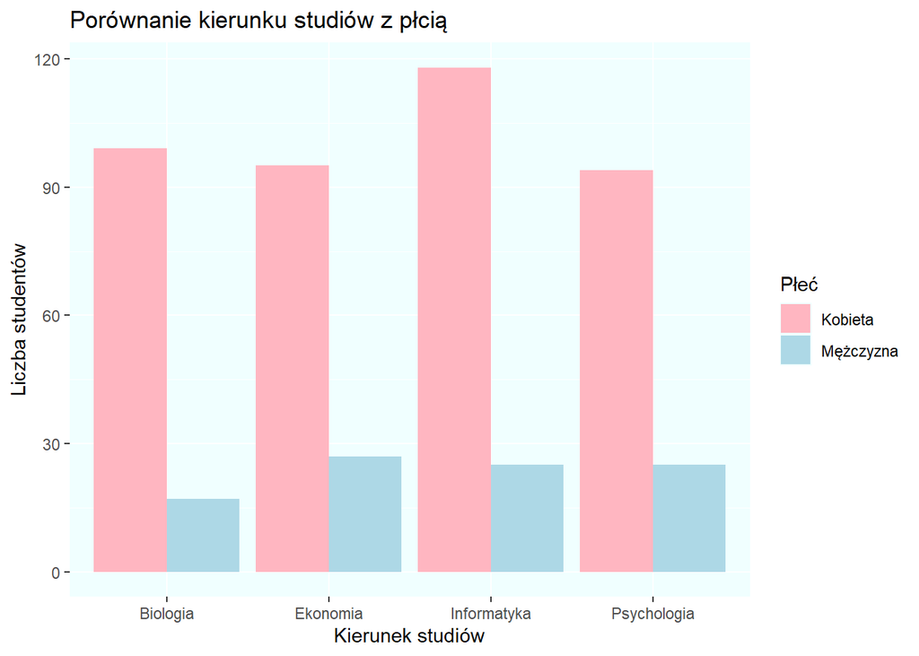

```r
library(ggplot2)
ggplot(dane, aes(x = Kierunek_studiów, fill = Płeć)) +
  geom_bar(position=position_dodge()) +
  labs(title = "Porównanie kierunku studiów z płcią",x = "Kierunek studiów",y = "Liczba studentów",fill = "Płeć") +
  scale_fill_manual(values = c("Kobieta" = "lightpink", "Mężczyzna" = "lightblue"))+
  theme(panel.background = element_rect(fill = "#F0FFFF"))
```

Jak możemy zauważyć na danej uczelni jest ogromna przewaga kobiet w stosunku do mężczyzn.Najchętniej wybieranym kierunkiem wśród kobiet jest Informatyka, za to wśród mężczyzn Ekonomia. Na Informatyce oraz Biologii najbardziej jest odczuwalna różnica w ilości kobiet a mężczyzn.

# Histogram dla średniej ocen

## Zadania

- Stwórz histogram dla średniej ocen, dodając linię reprezentującą jądrowy estymator gęstości oraz przerywane linie oznaczające średnią, modę i medianę. Oznacz osie, nadaj tytuł, zmień kolory histogramu oraz linii i dodaj legendę (legendy powinny uwzględniać styl linii, np. przerywana linia w legendzie odpowiada przerywanej linii na wykresie).
- Określ charakterystykę rozkładu: modalność, skośność i symetryczność.

## Rozwiązania

```r
library(moments)

srednia <- mean(dane$Średnia_ocen)
mediana <- median(dane$Średnia_ocen)
moda <- as.numeric(names(sort(table(dane$Średnia_ocen), decreasing = TRUE))[1])
mediana
```

```
## [1] 3.838122
```

```r
srednia
```

```
## [1] 3.836245
```

```r
moda
```

```
## [1] 5
```

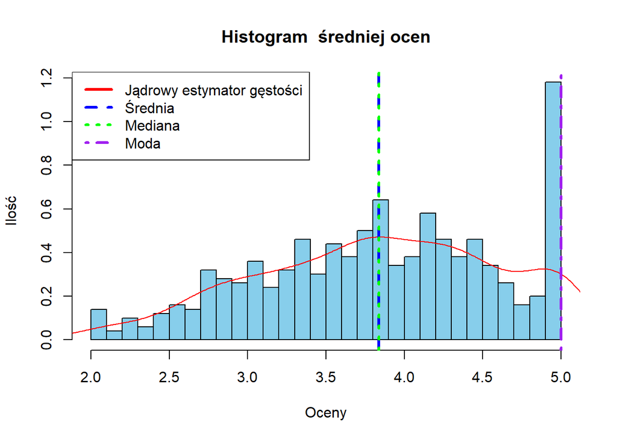

```r
hist(dane$Średnia_ocen,  breaks = 30, col = "skyblue",main = "Histogram  średniej ocen",xlab = "Oceny", ylab = "Ilość",probability = TRUE)
lines(density(dane$Średnia_ocen), col = "red")

abline(v = srednia, col = "blue", lty = 2, lwd = 3)
abline(v = mediana, col = "green", lty = 3, lwd = 3)
abline(v = moda, col = "purple", lty = 4, lwd = 3)

legend("topleft",legend = c("Jądrowy estymator gęstości", "Średnia", "Mediana", "Moda"), col = c("red", "blue", "green", "purple"), lty = c(1, 2, 3, 4), lwd = 3)
```

```r
print("Skośność: ")
```

```
## [1] "Skośność: "
```

```r
print(skewness(dane$Średnia_ocen))
```

```
## [1] -0.2494626
```

Rozkład nie jest symetryczny, ponieważ wartości średniej i mediany są bliskie sobie, ale wyraźnie niższe od mody.

# Wykresy pudełkowe dla czasu nauki a kierunek studiów

## Zadania

- Przy użyciu ggplot, narysuj wykresy pudełkowe dla czasu nauki w podziale na kierunek studiów. Wykres powinien mieć podpisane osie, tytuł oraz zmienione kolory.
- Na podstawie wykresu określ, czy rozkłady czasu nauki różnią się w zależności od kierunku. Który kierunek wymaga średnio najwięcej czasu, a który najmniej? Który kierunek charakteryzuje się największą wariancją? Czy są widoczne wartości odstające i jak je zidentyfikować?

## Rozwiązania

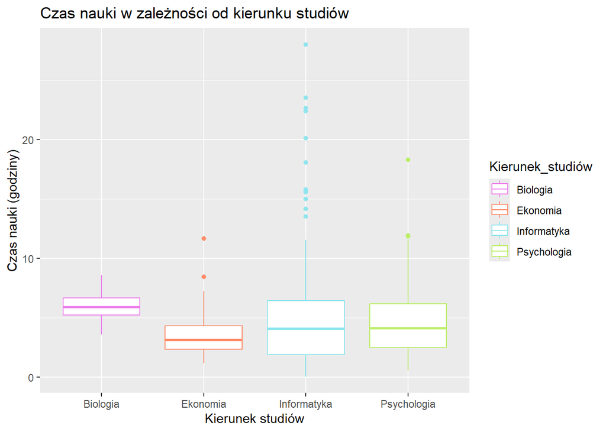

```r
library(ggplot2)
ggplot(dane)+
  geom_boxplot(aes(x=Kierunek_studiów, y=Czas_nauki, color = Kierunek_studiów))+
 labs( title = "Czas nauki w zależności od kierunku studiów",x = "Kierunek studiów",y = "Czas nauki (godziny)" )+
  scale_color_manual(values = c("Biologia"= "violet", "Ekonomia"="salmon1", "Informatyka"="cadetblue2", "Psychologia"="darkolivegreen2"))
```

```r
srednie <- tapply(dane$Czas_nauki, dane$Kierunek_studiów, mean)
print("Średni czas nauki ze względu na kierunek studiów")
```

```
## [1] "Średni czas nauki ze względu na kierunek studiów"
```

```r
print(srednie)
```

```
##    Biologia    Ekonomia Informatyka Psychologia
##    5.950783    3.473292    5.231401    4.605728
```

```r
print("Wariancja czasu nauki ze względu na kierunek studiów")
```

```
## [1] "Wariancja czasu nauki ze względu na kierunek studiów"
```

```r
wariancje <- tapply(dane$Czas_nauki, dane$Kierunek_studiów, var)
print(wariancje)
```

```
##    Biologia    Ekonomia Informatyka Psychologia
##   0.9546659   2.4699727  25.4790450   7.9957188
```

Czas nauki różni się ze względu na kierunek studiów. Studenci Biologii średnio poświęcają najwięcej czasu na naukę, za to studenci ekonomii najmniej.

Informatyka charakteryzuje się największą wariancją (Informatyka ma największy rozrzut wartości czyli najszersze pudełko).

W naszym zbiorze danych występują wartości odstające przedstawiono na wykresie jako pojedyncze punkty.

# Analiza rozkładu czasu nauki dla najliczniejszego kierunku studiów

## Zadania

- Wybierz czas nauki dla najliczniejszego kierunku studiów. Przeprowadź analizę rozkładu: przetestuj i porównaj dwa lub trzy różne rozkłady, wyestymuj ich parametry i oceń dopasowanie.

Rodziny rozkładów: wykładniczy `exp`, logarytmiczno-normalny `lnorm`, gamma `gamma`, normalny `norm`, t-Studenta `t`, Weibulla `weibull`, beta `beta`, jednostajny `unif`

## Rozwiązania

```r
library(fitdistrplus)
```

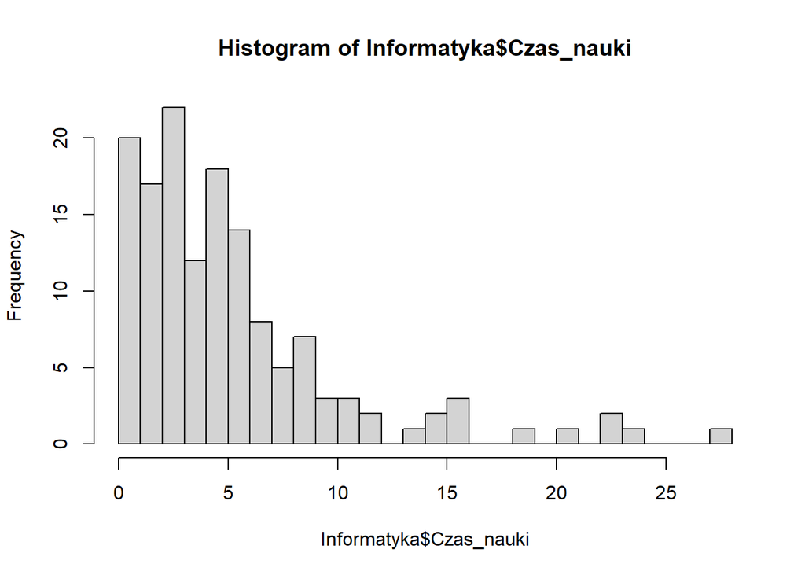

```r
Informatyka <- dane[which(dane$Kierunek_studiów == "Informatyka"),]

czas_nauki <- as.numeric(Informatyka$Czas_nauki)

hist(Informatyka$Czas_nauki, breaks=30)
```

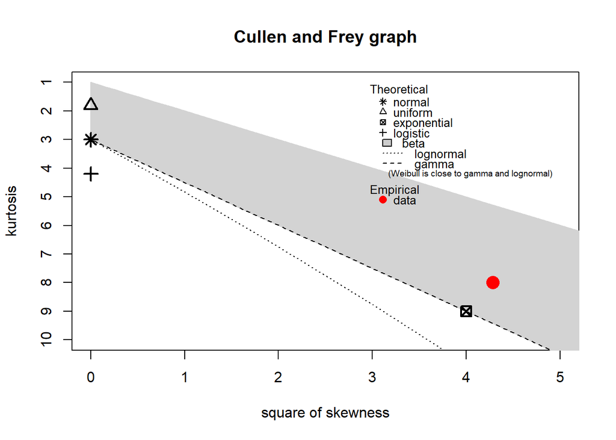

```
## summary statistics
## ------
## min:  0.05   max:  27.99
## median:  4.1
## mean:  5.231401
## estimated sd:  5.047677
## estimated skewness:  2.069725
## estimated kurtosis:  7.990454
```

```r
descdist(czas_nauki,discrete = FALSE)
```

```r
print("Na podstawie rysunku można zauważyć, że najlepszymi rozkładami do analizy będą rozkłady: gamma i logarytmiczno-normy. Sprawdzam rozkład Weibulla z ciekawości :).")
```

```
## [1] "Na podstawie rysunku można zauważyć, że najlepszymi rozkładami do analizy będą rozkłady: gamma i logarytmiczno-normy. Sprawdzam rozkład Weibulla z ciekawości :)."
```

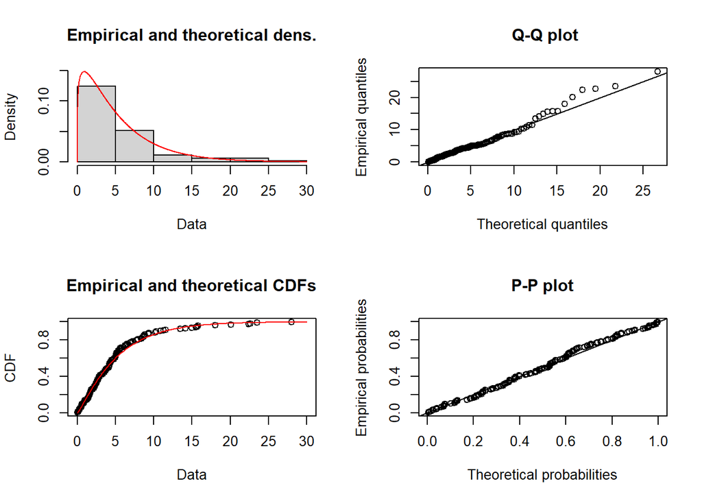

```r
fit_gamma <- fitdist(czas_nauki, "gamma")
fit_lnorm <- fitdist(czas_nauki, "lnorm")
fit_weibull <- fitdist(czas_nauki, "weibull")


par(mfrow = c(2, 2))
plot(fit_gamma)
```

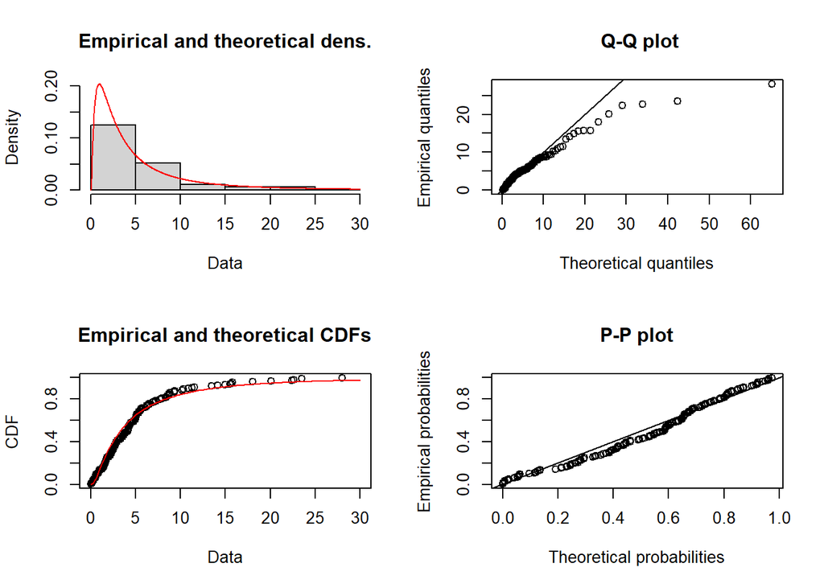

```r
plot(fit_lnorm)
```

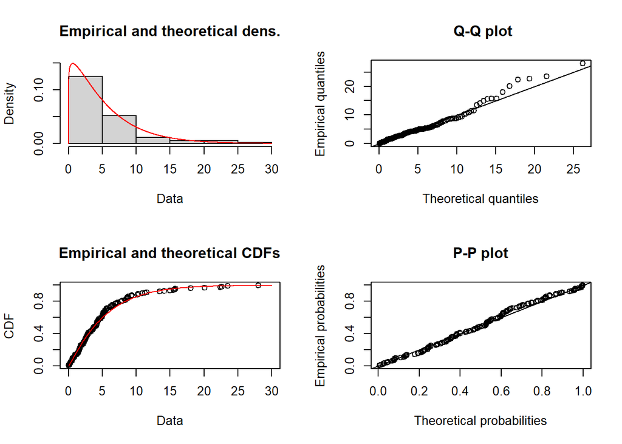

```r
plot(fit_weibull)
```

```r
gof <- gofstat(list(fit_gamma, fit_lnorm, fit_weibull), fitnames = c("Gamma", "Logarytmiczno-Normalny", "Weibull"))
print(gof)
```

```
## Goodness-of-fit statistics
##                                   Gamma Logarytmiczno-Normalny    Weibull
## Kolmogorov-Smirnov statistic 0.06183816             0.09206278 0.06575694
## Cramer-von Mises statistic   0.07904320             0.33120327 0.09744118
## Anderson-Darling statistic   0.49040872             1.94470086 0.59059378
##
## Goodness-of-fit criteria
##                                   Gamma Logarytmiczno-Normalny  Weibull
## Akaike's Information Criterion 760.3160               778.3466 761.0750
## Bayesian Information Criterion 766.2417               784.2723 767.0007
```

Porównywane rozkłady to : Gamma, Logistyczno-Normalny i Weibulla. Patrząc na parametry AIC i BIC można stwierdzić że najlepiej dopasowany jest rozkład Gamma.

# Wykres zależności średniej ocen od czasu nauki dla kierunku “Biologia”.

## Zadania

- Stwórz wykres punktowy, przedstawiający zależność średniej ocen od czasu nauki dla kierunku “Biologia”. Wykres powinien mieć podpisane osie, tytuł, zmienione kolory oraz legendę.
- Na podstawie wykresu określ, jaki rodzaj zależności występuje między zmiennymi. Oblicz korelację między średnią ocen a czasem nauki. Sprawdź założenia regresji liniowej, wyestymuj współczynniki prostej regresji i dodaj ją na wykres. Przeprowadź również diagnostykę modelu za pomocą odpowiednich wykresów.

## Rozwiązania

```r
library(lmtest)
```

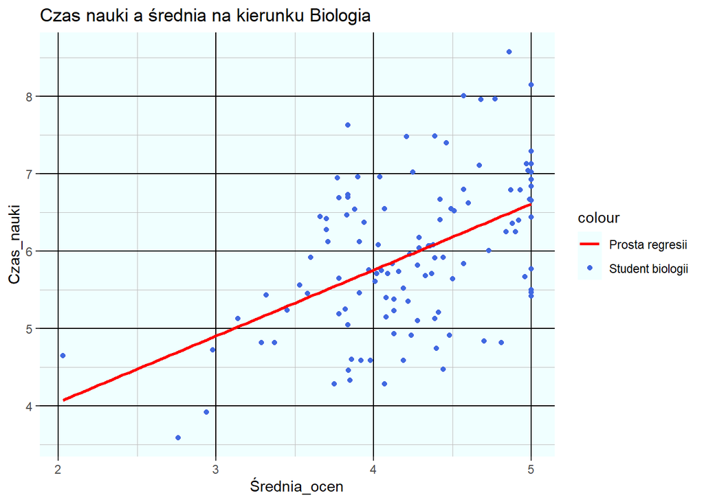

```r
biologia_dane <- dane[which(dane$Kierunek_studiów=="Biologia"),]
library(ggplot2)




ggplot(biologia_dane, aes(x=Średnia_ocen,y= Czas_nauki)) +
  geom_point(aes(color="Student biologii")) +
  geom_smooth(aes(color= "Prosta regresii"), method = "lm", se = FALSE) +
  scale_color_manual(values = c("Student biologii"="royalblue","Prosta regresii"= "red"))+
  labs(title = "Czas nauki a średnia na kierunku Biologia")+
   theme(panel.background = element_rect(fill="azure"),
    panel.grid.major = element_line(color="black"),
    panel.grid.minor = element_line(linewidth=0.2,color="grey"))
```

```r
print("Współczynnik korelacji")
```

```
## [1] "Współczynnik korelacji"
```

```r
print(cor(biologia_dane$Średnia_ocen, biologia_dane$Czas_nauki))
```

```
## [1] 0.4861039
```

```r
# 1.Testowanie postaci modelu liniowego
model <- lm(Czas_nauki ~ Średnia_ocen, data = biologia_dane)
summary(model)
```

```
##
## Call:
## lm(formula = Czas_nauki ~ Średnia_ocen, data = biologia_dane)
##
## Residuals:
##      Min       1Q   Median       3Q      Max
## -1.66406 -0.55105 -0.01174  0.54562  2.08713
##
## Coefficients:
##              Estimate Std. Error t value Pr(>|t|)
## (Intercept)    2.3409     0.6130   3.819 0.000219 ***
## Średnia_ocen   0.8543     0.1438   5.939 3.17e-08 ***
## ---
## Signif. codes:  0 '***' 0.001 '**' 0.01 '*' 0.05 '.' 0.1 ' ' 1
##
## Residual standard error: 0.8576 on 114 degrees of freedom
## Multiple R-squared:  0.2363, Adjusted R-squared:  0.2296
## F-statistic: 35.27 on 1 and 114 DF,  p-value: 3.171e-08
```

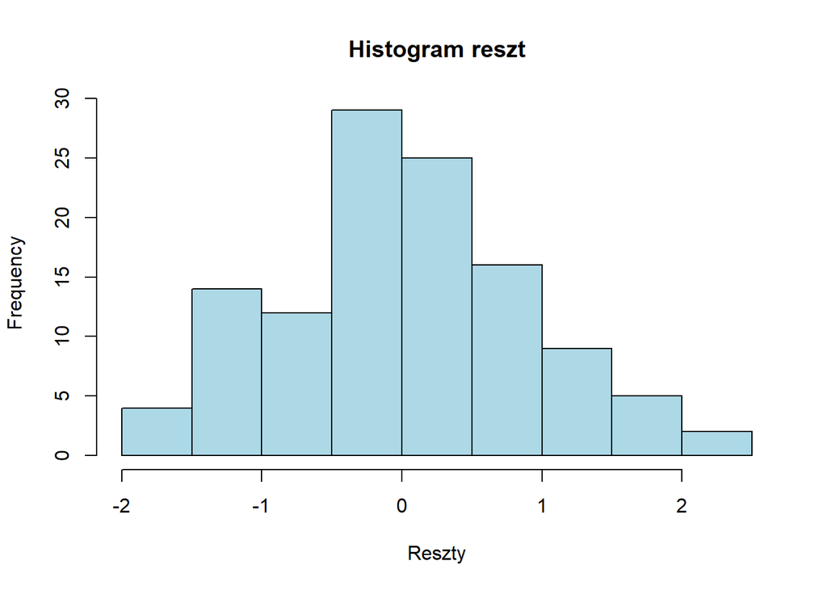

```r
# 2. Histogram reszt
residuals <- residuals(model)
hist(residuals, main = "Histogram reszt", xlab = "Reszty", col = "lightblue", border = "black")
```

```r
# 3. Test Shapiro-Wilka test normalnosci
shapiro_test <- shapiro.test(residuals)
print(shapiro_test)
```

```
##
##  Shapiro-Wilk normality test
##
## data:  residuals
## W = 0.98454, p-value = 0.2049
```

```r
# 4. Test Breuscha-Pagana dla homoskedastyczności
bp_test <- bptest(model)
print(bp_test)
```

```
##
##  studentized Breusch-Pagan test
##
## data:  model
## BP = 0.68068, df = 1, p-value = 0.4094
```

```r
# 5. Sprawdzenie autokorelacji reszt za pomocą testu Durbin-Watsona
library("car")
durbinWatsonTest(model)
```

```
##  lag Autocorrelation D-W Statistic p-value
##    1      0.07392102      1.824631   0.364
##  Alternative hypothesis: rho != 0
```

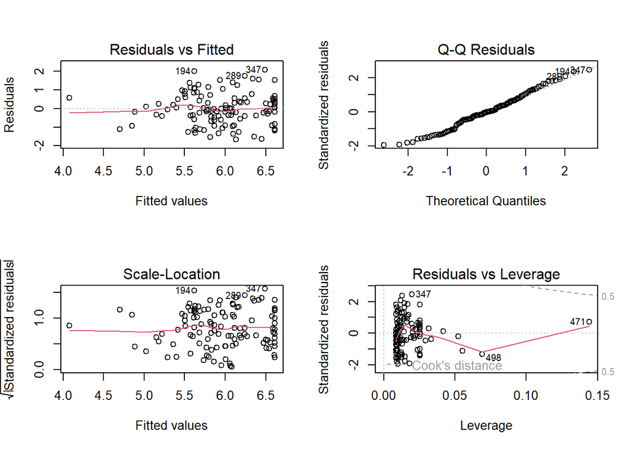

```r
#Diagnostyka modelu
par(mfrow=c(2,2))
plot(model)
```

Na podstwie wykresu możemy zauważyć, że istnieje zależniść liniowa pomiędzy zmiennymi, ponieważ gdy Student chce mieć lepsze oceny to musi więcej czasu poświęcić na naukę.

Testowanie postaci modelu liniowego : p-wartość wynosi 3.171e-08, więc istnieje statystycznie istotna zależność liniowa między tymi zmiennymi.

Test Shapiro-Wilka test normalnosci :p-wartość jest większa od przyjętego poziomu istotności,więc reszty mają rozkład normalny.

Test Breuscha-Pagana dla homoskedastyczności: p-wartość jest większa niż przyjęty poziom istotności to nie odrzucamy hipotezy zerowej, że wariancja jest jednorodna.

Testu Durbin-Watsona :p-wartość jest większa niż przyjęty poziom istotności więc nie ma statystycznych dowodów na występowanie autokorelacji reszt.

Residuals vs Fitted : Punkty na wykresie są dość losowo rozproszone wokół czerwonej linii. To wskazuje, że model spełnia założenie liniowości.Czerwona linia jest dosyć płaska, że średnia reszt nie zależy od wartości dopasowanych, co jest pozytywne.

Q-Q Residuals : Większość punktów układa się wzdłuż linii prostej y=x, co wskazuje, że reszty mają w przybliżeniu rozkład normalny.

Scale_location : Punkty są stosunkowo równomiernie rozmieszczone wokół czerwonej linii, co sugeruje jednorodność wariancji (homoskedastyczność).